# Hub Connectivity

# Setup

```r
library(rmdformats)
library(rmarkdown)
library(dplyr)
library(stringr)
library(readr)
library(tidyr)
library(tibble)
library(ggplot2)
library(magrittr)
library(WGCNA)
library(DT)
library(pander)
library(pheatmap)
library(here)
```

# Data Import

```r
placenta_data <- read_csv(here("data/placenta_data_wgcna.csv")) %>%
  column_to_rownames("sample_id")

gene_entrez_anno <- read_csv(here("data/gene_entrez_anno.csv.gz"))

mergedColours <- read_rds(here("data/mergedColours.rds"))

left_group <- read_csv(here("data/turquoise_left_group.csv.gz"))
right_group <- read_csv(
  here("data/turquoise_right_group.csv.gz")
  )

soft_power <- 12
```

# Hub connectivity

Intramodular connectivity is essentially the module membership of genes which may reveal regulatory changes in gene expressions. The intramodular connectivity measure is used to define the most highly connected intramodular hub gene as the module representative and can also show intramodular hub genes that are highly correlated with the module eigengene.

- `topHubGenesTotal` contains the top hub genes from the total connectivity of all genes
- `topHubGenesInModule` are top genes selected by conectivity in each module
- In`topHubGenesTotalAll` it’s essentially similar to the table before but contains all the genes as `distinct` hasn’t been called on the module and genes
- In `topHubGenesInModuleAll` it’s the same as `topHubGenesInModule` except that it has all genes in each module ranked by their connectivity

## Get gene connectivity info for each module

```r
connectivityGenes <- intramodularConnectivity.fromExpr(placenta_data,
                                                       mergedColours,
                                                       scaleByMax = TRUE)
```

```
##  softConnectivity: FYI: connecitivty of genes with less than 16 valid samples will be returned as NA.
##  ..calculating connectivities..
```

```r
topHubGenesTotal <- cbind(gene_id = colnames(placenta_data),
                          module = mergedColours,
                          Connectivity = connectivityGenes) %>%
  as_tibble() %>%
  arrange(desc(Connectivity.kTotal)) %>%
  distinct(module, .keep_all = TRUE) %>%
  left_join(gene_entrez_anno,
            by = "gene_id") %>%
  dplyr::select(-Connectivity.kOut,
                -Connectivity.kDiff) %>%
  distinct(gene_id,
           .keep_all = TRUE)

topHubGenesTotalAll <- cbind(gene_id = colnames(placenta_data),
                             module = mergedColours,
                             Connectivity = connectivityGenes) %>%
  as_tibble() %>%
  arrange(desc(Connectivity.kTotal)) %>%
  left_join(gene_entrez_anno,
            by = "gene_id") %>%
  dplyr::select(-Connectivity.kOut,
                -Connectivity.kDiff) %>%
  distinct(gene_id,
           .keep_all = TRUE)

topHubGenesInModule <- cbind(gene_id = colnames(placenta_data),
                             module = mergedColours,
                             Connectivity = connectivityGenes) %>%
  as_tibble() %>%
  arrange(desc(Connectivity.kWithin)) %>%
  distinct(module, .keep_all = TRUE) %>%
  left_join(gene_entrez_anno,
            by = "gene_id") %>%
  dplyr::select(-Connectivity.kOut,
                -Connectivity.kDiff) %>%
  distinct(gene_id, .keep_all = TRUE)

topHubGenesInModuleAll <- cbind(gene_id = colnames(placenta_data),
                                module = mergedColours,
                                Connectivity = connectivityGenes) %>%
  as_tibble() %>%
  arrange(desc(Connectivity.kWithin)) %>%
  left_join(gene_entrez_anno,
            by = "gene_id") %>%
  dplyr::select(-Connectivity.kOut,
                -Connectivity.kDiff) %>%
  distinct(gene_id,
           .keep_all = TRUE)
```

## Get the top 10 hub genes across each module

```r
modules <- topHubGenesInModuleAll$module %>% unique()

module_list <- modules %>%
  as.data.frame() %>%
  set_colnames("modules") %>%
  split(modules)


for(i in modules) {
  topgenes <- topHubGenesInModuleAll %>%
    dplyr::filter(module == i) %>%
    dplyr::arrange(desc(Connectivity.kWithin)) %>%
    dplyr::select(gene_name) %>%
    head(10) %>%
    as.matrix() %>%
    as.character()

  module_list[[i]] <- paste0(topgenes)
}

module_tbl <- module_list %>%
  as.data.frame() %>%
  dplyr::select(-grey) %>%
  t()

module_tbl %>%
  as.data.frame() %>%
  rownames_to_column("modules") %>%
  as_tibble() %>%
  write_csv(here("data/supp_figureS2.csv"),
            col_names = FALSE)
```

Save the module genes

```r
write_csv(topHubGenesInModuleAll,
          here("data/topHubGenesInModuleAll.csv"))
```

Print the top 5 hub genes by module connectivity. Taking only the first 5 lines of the table for viewing.

```r
topHubGenesTotalAll %>%
  group_by(module) %>%
  arrange(desc(Connectivity.kWithin)) %>%
  top_n(5,
        Connectivity.kTotal) %>%
  head(n = 5) %>%
  pander(split.table = Inf)
```

| gene_id | module | Connectivity.kTotal | Connectivity.kWithin | gene_name | gene_biotype | chromosome | length | entrezgene |
| --- | --- | --- | --- | --- | --- | --- | --- | --- |
| ENSG00000165805 | brown | 757.7 | 1 | C12orf50 | protein_coding | 12 | 53999 | 160419 |
| ENSG00000124693 | salmon | 316.8 | 1 | HIST1H3B | protein_coding | 6 | 472 | NA |
| ENSG00000101336 | green | 107.2 | 1 | HCK | protein_coding | 20 | 49669 | 3055 |
| ENSG00000162517 | black | 769.6 | 0.9804 | PEF1 | protein_coding | 1 | 15035 | 553115 |
| ENSG00000162924 | brown | 790.5 | 0.9802 | REL | protein_coding | 2 | 50090 | 5966 |

## Module Membership

By binding the connectivity results with the counts data, the module membership of each gene can be retrieved. This allows identification of genes that are present within highly distinct modules and what their enriched pathways are, as these may be significant driving factors identified in the network.

```r
top_within_connectivity <- topHubGenesInModuleAll %>%
  dplyr::select("gene_id",
                "module",
                "gene_name",
                "Connectivity.kTotal",
                "Connectivity.kWithin") %>%
  group_by(module) %>%
  top_n(10)

top_within_connectivity %>%
  write_csv(here("data/top_within_connectivity.csv"))

top_total_connectivity <- topHubGenesInModuleAll %>%
  dplyr::filter(!module %in% "grey") %>%
  dplyr::select("gene_id",
                "module",
                "gene_name",
                "Connectivity.kWithin",
                "Connectivity.kTotal") %>%
  group_by(module) %>%
  top_n(10)

top_total_connectivity %>%
  write_csv(here("data/top_total_connectivity.csv"))
```

## Housekeeping Genes Check

Sanity check of expression of housekeeping genes

```r
housekeeping <- data.frame(
  gene_id = c("ENSG00000112592", "ENSG00000073578", "ENSG00000164924",
              "ENSG00000165704", "ENSG00000256269", "ENSG00000111640",
              "ENSG00000075624", "ENSG00000179091", "ENSG00000198900"),
  gene_name = c("TBP", "SDHA", "YWHAZ",
                "HPRT1", "HMBS", "GAPDH",
                "actinB", "CYC1", "TOP1")
)

topHubGenesInModuleAll %>%
  dplyr::filter(gene_id %in% housekeeping$gene_id)
```

```
## # A tibble: 5 × 9
##   gene_id module Connectivity.kTotal Connectivity.kWithin gene_name gene_biotype
##   <chr>   <chr>                <dbl>                <dbl> <chr>     <chr>
## 1 ENSG00… black                643.                 0.763 CYC1      protein_cod…
## 2 ENSG00… turqu…                46.2                0.306 ACTB      protein_cod…
## 3 ENSG00… turqu…                22.4                0.170 HPRT1     protein_cod…
## 4 ENSG00… grey                 122.                NA     GAPDH     protein_cod…
## 5 ENSG00… grey                  93.6               NA     TOP1      protein_cod…
## # ℹ 3 more variables: chromosome <chr>, length <dbl>, entrezgene <dbl>
```

```r
# Insulin superfamily
insulin_family <- data.frame(
  gene_name = c(
    "RLN1", "IGF1", "IGF2",
    "INS", "INSL3", "INSL4",
    "INSL5", "INSL6", "RLN3"
  )
)

topHubGenesInModuleAll %>%
  dplyr::filter(gene_name %in% insulin_family$gene_name)
```

```
## # A tibble: 3 × 9
##   gene_id module Connectivity.kTotal Connectivity.kWithin gene_name gene_biotype
##   <chr>   <chr>                <dbl>                <dbl> <chr>     <chr>
## 1 ENSG00… turqu…                35.7                0.191 IGF2      protein_cod…
## 2 ENSG00… grey                 149.                NA     IGF1      protein_cod…
## 3 ENSG00… grey                 125.                NA     INSL4     protein_cod…
## # ℹ 3 more variables: chromosome <chr>, length <dbl>, entrezgene <dbl>
```

Save all gene modules

```r
#topHubGenesInModuleAll
module_genes_list <- topHubGenesInModuleAll %>%
  dplyr::select("Gene ID" = "gene_id",
                "Gene Name" = "gene_name",
                "Module" = "module",
                "Network Connectivity" = "Connectivity.kTotal",
                "Intramodular Connectivity" = "Connectivity.kWithin",
                "Chromosome" = "chromosome",
                "Entrez ID" = "entrezgene") %>%
  mutate(`Network Connectivity` = round(`Network Connectivity`,
                                        digits = 2),
         `Intramodular Connectivity` = round(`Intramodular Connectivity`,
                                             digits = 2)) %>%
  split(.$Module)

writexl::write_xlsx(
  list("TableS2 Black Module" = module_genes_list$black,
       "TableS2 Blue Module" = module_genes_list$blue,
       "TableS2 Brown Module" = module_genes_list$brown,
       "TableS2 Green Module" = module_genes_list$green,
       "TableS2 Greenyellow Module" = module_genes_list$greenyellow,
       "TableS2 Pink Module" = module_genes_list$pink,
       "TableS2 Purple Module" = module_genes_list$purple,
       "TableS2 Salmon Module" = module_genes_list$salmon,
       "TableS2 Turquoise Module" = module_genes_list$turquoise),
  path = here("data/tableS2.xlsx"))
```

# Split Turquoise Groups

Filter out the groups

```r
topHubGenesInModuleAll %>%
  dplyr::filter(gene_name %in% right_group$right_group)
```

```
## # A tibble: 10 × 9
##    gene_id         module    Connectivity.kTotal Connectivity.kWithin gene_name
##    <chr>           <chr>                   <dbl>                <dbl> <chr>
##  1 ENSG00000147454 turquoise                29.5                0.523 SLC25A37
##  2 ENSG00000166947 turquoise                24.4                0.463 EPB42
##  3 ENSG00000183508 turquoise                24.7                0.446 FAM46C
##  4 ENSG00000159023 turquoise                21.4                0.424 EPB41
##  5 ENSG00000158856 turquoise                20.9                0.373 DMTN
##  6 ENSG00000004939 turquoise                19.2                0.363 SLC4A1
##  7 ENSG00000145335 turquoise                19.8                0.349 SNCA
##  8 ENSG00000136929 turquoise                19.7                0.334 HEMGN
##  9 ENSG00000206172 turquoise                19.1                0.280 HBA1
## 10 ENSG00000158578 turquoise                32.4                0.277 ALAS2
## # ℹ 4 more variables: gene_biotype <chr>, chromosome <chr>, length <dbl>,
## #   entrezgene <dbl>
```

```r
topHubGenesInModuleAll %>%
  dplyr::filter(gene_name %in% right_group$right_group) %>%
  dplyr::select(Connectivity.kWithin) %>%
  sum()/10
```

```
## [1] 0.3831632
```

```r
topHubGenesInModuleAll %>%
  dplyr::filter(gene_name %in% left_group$left_group)
```

```
## # A tibble: 26 × 9
##    gene_id         module    Connectivity.kTotal Connectivity.kWithin gene_name
##    <chr>           <chr>                   <dbl>                <dbl> <chr>
##  1 ENSG00000120899 turquoise                45.0                1     PTK2B
##  2 ENSG00000129521 turquoise                44.0                0.965 EGLN3
##  3 ENSG00000115590 turquoise                38.0                0.879 IL1R2
##  4 ENSG00000169891 turquoise                36.0                0.856 REPS2
##  5 ENSG00000135919 turquoise                37.9                0.853 SERPINE2
##  6 ENSG00000100196 turquoise                43.6                0.851 KDELR3
##  7 ENSG00000012232 turquoise                45.1                0.844 EXTL3
##  8 ENSG00000189159 turquoise                49.1                0.837 HN1
##  9 ENSG00000115414 turquoise                35.5                0.822 FN1
## 10 ENSG00000179761 turquoise                33.2                0.795 PIPOX
## # ℹ 16 more rows
## # ℹ 4 more variables: gene_biotype <chr>, chromosome <chr>, length <dbl>,
## #   entrezgene <dbl>
```

```r
topHubGenesInModuleAll %>%
  dplyr::filter(gene_name %in% left_group$left_group) %>%
  dplyr::select(Connectivity.kWithin) %>%
  sum()/26
```

```
## [1] 0.7146748
```

```r
r_m <- topHubGenesInModuleAll %>%
  dplyr::filter(gene_name %in% right_group$right_group)
r_m <- r_m %>%
  dplyr::select("Gene ID" = "gene_id",
                "Gene Name" = "gene_name",
                "Intramodular Connectivity" = "Connectivity.kWithin",
                "Chromosome" = "chromosome",
                "Module" = "module")

l_m <- topHubGenesInModuleAll %>%
  dplyr::filter(gene_name %in% left_group$left_group)
l_m <- l_m %>%
  dplyr::select("Gene ID" = "gene_id",
                "Gene Name" = "gene_name",
                "Intramodular Connectivity" = "Connectivity.kWithin",
                "Chromosome" = "chromosome",
                "Module" = "module")

turq_groups <- list("right_group" = r_m, "left_group" = l_m)
```

## Plot the Right Group

```r
DT::datatable(turq_groups$right_group)
```

|  | Gene ID | Gene Name | Intramodular Connectivity | Chromosome | Module |
| --- | --- | --- | --- | --- | --- |
| 1 | ENSG00000147454 | SLC25A37 | 0.5234885556160354 | 8 | turquoise |
| 2 | ENSG00000166947 | EPB42 | 0.4632643755267969 | 15 | turquoise |
| 3 | ENSG00000183508 | FAM46C | 0.4459079405251025 | 1 | turquoise |
| 4 | ENSG00000159023 | EPB41 | 0.4237856757242974 | 1 | turquoise |
| 5 | ENSG00000158856 | DMTN | 0.3728387904262668 | 8 | turquoise |
| 6 | ENSG00000004939 | SLC4A1 | 0.3625682315272852 | 17 | turquoise |
| 7 | ENSG00000145335 | SNCA | 0.348939578455648 | 4 | turquoise |
| 8 | ENSG00000136929 | HEMGN | 0.3338951193579855 | 9 | turquoise |
| 9 | ENSG00000206172 | HBA1 | 0.2795266589942519 | 16 | turquoise |
| 10 | ENSG00000158578 | ALAS2 | 0.2774174826126214 | X | turquoise |

## Plot the Left Group

```r
DT::datatable(turq_groups$left_group)
```

|  | Gene ID | Gene Name | Intramodular Connectivity | Chromosome | Module |
| --- | --- | --- | --- | --- | --- |
| 1 | ENSG00000120899 | PTK2B | 1 | 8 | turquoise |
| 2 | ENSG00000129521 | EGLN3 | 0.9653233200260108 | 14 | turquoise |
| 3 | ENSG00000115590 | IL1R2 | 0.8789610204390838 | 2 | turquoise |
| 4 | ENSG00000169891 | REPS2 | 0.8558652608002573 | X | turquoise |
| 5 | ENSG00000135919 | SERPINE2 | 0.8534127485506774 | 2 | turquoise |
| 6 | ENSG00000100196 | KDELR3 | 0.8505436242867073 | 22 | turquoise |
| 7 | ENSG00000012232 | EXTL3 | 0.8440772046809761 | 8 | turquoise |
| 8 | ENSG00000189159 | HN1 | 0.8373872460887424 | 17 | turquoise |
| 9 | ENSG00000115414 | FN1 | 0.8223240391786508 | 2 | turquoise |
| 10 | ENSG00000179761 | PIPOX | 0.7947461984797282 | 17 | turquoise |

[output cut: 16 more lines]

## Save the turquoise groups

```r
writexl::write_xlsx(
  list("TableS3 Right Group" = turq_groups$right_group,
       "TableS3 Left Group" = turq_groups$left_group),
  path = here("data/tableS3.xlsx"))
```

A high connectivity between genes within the same module may mean that module is the most distinct from the rest of the modules. This makes measurement of intramodular connectivity an import property of the formed network. Connectivity is plotted here

# Plot Module Connectivity

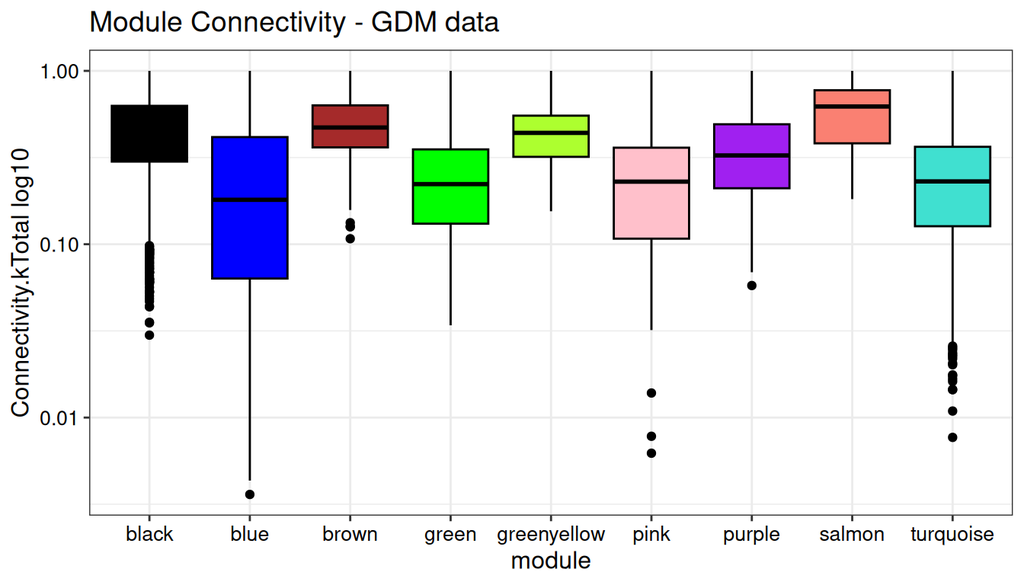

```r
cols <- levels(as.factor(topHubGenesInModule$module))
cols <- cols[!(cols %in% c("grey"))]

hub_connectivity <- topHubGenesTotalAll %>%
  dplyr::filter(module != "grey") %>%
  ggplot(
    aes(x = module,
        y = Connectivity.kWithin,
        fill = module)
  ) +
  geom_boxplot(colour = "black") +
  ggtitle("Module Connectivity - GDM data") +
  scale_fill_manual(values = cols) +
  scale_y_log10() +
  ylab("Connectivity.kTotal log10") +
  theme_bw() +
  theme(axis.title = element_text(colour = "black",
                                  size = 12),
        axis.text = element_text(colour = "black",
                                 size = 10),
        plot.title = element_text(colour = "black",
                                  size = 14),
        legend.position = "none")

hub_connectivity
```

## Save figure

```r
ggsave(filename = "hub_connectivity.png",
       plot = hub_connectivity,
       device = "png",
       path = here("figures/"),
       dpi = 300,
       scale = 1,
       width = 2500,
       height = 1500,
       units = "px")
```